# PySpark 与基于开发容器的集群搭建概述

## 相关介绍

本教程将介绍如何使用开发容器（Dev Container）环境，快速搭建和体验 PySpark 集群，助力大数据分析与分布式计算的学习与实践。

1. PySpark 是 Apache Spark 的 Python API 接口，允许用户通过 Python 编写 Spark 程序，具备强大的分布式计算能力，广泛应用于大规模数据处理、机器学习、图计算和流处理等场景。
2. 为了简化 Spark 的部署和调试过程，可通过 开发容器 技术（如 Docker + Docker Compose）快速搭建一个可用于测试、开发甚至教学的 PySpark 分布式集群环境。

## Spark的主要流行模式

Apache Spark 的主要流行运行模式（部署模式）有以下几种，每种模式都适合不同的应用场景和基础设施环境：

| 对比维度 | **Local** | **Standalone** | **YARN** | **Kubernetes (K8s)** |
| --- | --- | --- | --- | --- |
| **资源管理器** | 无 | Spark 自带 | Hadoop YARN | Kubernetes |
| **部署复杂度** | 极低（本地即可） | 低（部署 Spark 即可） | 中（需完整 Hadoop 环境） | 高（需容器技术与 K8s 集群） |
| **是否分布式** | 否（单机） | 是（Spark Master + Worker） | 是（YARN ResourceManager 管理） | 是（基于 K8s Pods 调度） |
| **容错性** | 低（无恢复机制） | 中（Worker 故障可恢复） | 高（YARN 提供资源与任务恢复） | 高（K8s 自动重启、容器隔离） |
| **动态资源扩展** | 否 | 支持有限 | 支持（需配置） | 原生支持自动扩缩容 |
| **典型部署方式** | 本机命令行或 Jupyter | 手动启动 Spark Master/Worker | Hadoop 集群中部署 Spark | Docker 容器运行于 K8s 中 |
| **依赖组件** | Python/Java | Spark | Spark + Hadoop/YARN | Spark + Docker + Kubernetes |
| **适用场景** | 本地开发测试 | 小型集群或教学实验 | 企业级大数据处理 | 云原生、大规模弹性调度 |
| **资源隔离** | 无 | 有限（基于端口和配置） | 好（支持队列、容器、用户隔离） | 极好（Pod 级别资源隔离） |
| **监控与可视化** | Spark UI（本地） | Spark UI（默认 4040） | Spark UI + YARN Web UI | Spark UI + Kubernetes Dashboard |

## 典型开发容器的组成结构

| 文件或组件 | 描述 |
| --- | --- |
| **Dockerfile** | 构建容器镜像的基础文件，定义操作系统、语言环境、依赖库、工具链等。 |
| **devcontainer.json** | 配置开发容器行为（启动命令、端口映射、默认终端、VS Code 插件等），VS Code 专属配置文件。 |
| **docker-compose.yaml** | 启动多容器服务（如 Spark Master + Workers + Hadoop），用于模拟集群或复杂系统。 |
| **Volume 映射设置** | 将本地文件或目录（如数据集、脚本）挂载进容器以实现持久化与调试。 |
| **VS Code Remote Development** | 插件（Remote - Containers）支持 IDE 远程连接容器 |

## PySpark Local模式部署及测试

### PySpark Local模式部署

1. 新建`.devcontainer`文件夹，目录如下：

```
my-project/
├── .devcontainer/
│   ├── Dockerfile
│   ├── devcontainer.json
│   └── docker-compose.yaml
├── notebooks/
└── README.md
```

2. 新建`devcontaienr.json`文件，文件内容如下：

```
{
    // 开发容器名称
    "name": "PySpark local cluster",
    // 指定Docker Compose配置文件路径
    "dockerComposeFile": ["./docker-compose.yaml"],
    // 指定服务名称（与docker-compose.yaml中的服务名称一致）
    "service": "spark",
    // 指定容器的工作目录
    "workspaceFolder": "/home/jovyan/code",
    // VS Code的自定义配置
    "customizations": {
        "vscode" : {
            "settings": {
                // 配置终端使用bash
                "terminal.integrated.profiles.linux": {
                    "bash": {
                        "path": "/bin/bash"
                    }
                },
                "terminal.integrated.defaultProfile.linux": "bash",

                // 启用Python代码检查和pylint
                "python.linting.enabled": true,
                "python.linting.pylintEnabled": true
            },
            // 预安装的VS Code扩展
            "extensions": [
                "ms-python.python",
    	        "ms-toolsai.jupyter"
            ]
        }
    }
}
```

3. 新建`docker-compose.yaml`文件，文件内容如下：

```
version: '3' # Docker Compose文件版本
services:
  spark: # 服务名称，需与Dockerfile中的服务名称一致
    build:
      context: .  # 构建上下文目录，即.devcontainer目录
      dockerfile: Dockerfile # 指定Dockerfile文件
    #image: bitnami/spark:3.5 # 使用Bitnami的Spark镜像
    #image: jupyter/pyspark-notebook:latest # 使用Jupyter的PySpark Notebook镜像
    volumes:
      - ..:/home/jovyan/code # 挂载上级目录到容器内的/home/jovyan/code
    ports:
      - "6666:6666" # 端口映射
      - "4040:4040" # 端口映射
    command: start.sh jupyter notebook --NotebookApp.token='' --NotebookApp.disable_check_xsrf=true --NotebookApp.allow_origin='*' --NotebookApp.ip='0.0.0.0'
    # 启动容器时运行的命令，启动 Jupyter Notebook 并允许远程访问
```

4. 新建`Dockerfile`文件，文件内容如下：

```
# 选择你想要的基础镜像
FROM jupyter/pyspark-notebook:latest

# conda环境名称和Python版本
ARG conda_env=vscode_pyspark
ARG py_ver=3.11

# 使用 mamba 创建新的 conda 环境，并安装 ipython 和 ipykernel
RUN mamba create --yes -p "${CONDA_DIR}/envs/${conda_env}" python=${py_ver} ipython ipykernel && \
    mamba clean --all -f -y

# pip从阿里云镜像在conda环境中安装 PySpark 和其他常用库
RUN "${CONDA_DIR}/envs/${conda_env}/bin/pip" install pyspark pandas findspark --no-cache-dir -i https://mirrors.aliyun.com/pypi/simple

# 让新建的 conda 环境成为默认环境
RUN echo "conda activate ${conda_env}" >> "${HOME}/.bashrc"
```

6. 注意事项：  
   6.1 如果在查看 Docker 日志时遇到镜像拉取失败等问题，可通过配置 Docker 代理或使用 VPN 进行解决。建议及时查看日志以定位具体错误原因。  
   6.2 若运行 PySpark 测试代码时出现 `JavaPackage' object is not callable` 错误，且基础镜像已包含 Java，可借助 findspark 正确初始化 Spark 环境变量和依赖（相关代码见下一节），以确保环境配置无误。

### PySpark Local模式测试

```python
import findspark
findspark.init()

from pyspark.sql import SparkSession
# 创建了一个 SparkSession 对象，并指定 master 为 "local"
# 表示在本地模式下运行（即只使用当前这台机器，不连接集群）。
# SparkSession 是与 Spark 进行交互的入口
spark = SparkSession.builder.master("local").getOrCreate()
# SparkContext 是 Spark 的核心，
# 用于连接到 Spark 集群并负责与集群管理器进行通信
# 可以用来执行分布式任务
# 在终端中不需要显示创建 SparkContext
sc = spark.sparkContext
sc
```

**SparkContext**

[Spark UI](http://8e6a42a2dbc5:4040)

**Version**

`v3.5.0`

**Master**

`local`

**AppName**

`pyspark-shell`

```python
# 从指定的文件创建一个 RDD。
data = sc.textFile('demo_file.txt')
print(type(data))
# collect() 会将 RDD 中的元素收集到一个列表中。
data.collect()
```

```
<class 'pyspark.rdd.RDD'>
```

```
['This is just a demo file. ',
 'Normally, a file this small would have no reaon to be on HDFS.']
```

- 端口转发：容器端口转发（Port Forwarding）是实现容器与外部系统通信的重要机制。
- Spark UI 访问：可通过浏览器访问 Spark UI（http://localhost:4040/executors/ ），查看任务执行与资源分配情况。

[figure not shown]

- Docker desktop容器界面

[figure not shown]

### PySpark Standalone模式部署

1. 新建`.devcontainer`文件夹，目录如下：

```
my-project/
├── .devcontainer/
│   ├── Dockerfile
│   ├── devcontainer.json
│   └── docker-compose.yaml
├── notebooks/
└── README.md
```

2. 新建`devcontainer.json`文件，内容如下：

```
{
    "name": "PySpark cluster",
    "dockerComposeFile": ["./docker-compose.yaml"],
    "service": "spark-master",
    "workspaceFolder": "/home/jovyan/code",

    "customizations": {
        "vscode" : {
            "settings": {
                "terminal.integrated.profiles.linux": {
                    "bash": {
                        "path": "/bin/bash"
                    }
                },
                "terminal.integrated.defaultProfile.linux": "bash",
                "python.linting.enabled": true,
                "python.linting.pylintEnabled": true
            },
            "extensions": [
                "ms-python.python",
    	        "ms-toolsai.jupyter"
            ]
        }
    }
}
```

3. 新建`docker-compose.yaml`文件（一个master两个worker节点），内容如下：

```
version: '3'

networks:
  sparknet:
    name: sparknet
    driver: bridge

services:
  spark-master:
    build:
      context: .
      dockerfile: Dockerfile
    user: root
    container_name: spark-master
    hostname: spark-master
    ports:
      - "8888:8888" # Jupyter Notebook
      - "7077:7077" # Spark Master
      - "8080:8080" # Spark Master Web UI
      - "8081:8081"
    volumes:
      - ..:/home/jovyan/code
    networks:
      - sparknet
    command: bash -c "/usr/local/spark/sbin/start-master.sh && start.sh jupyter notebook --NotebookApp.token='' --NotebookApp.disable_check_xsrf=true --NotebookApp.allow_origin='*' --NotebookApp.ip='0.0.0.0'"

  spark-worker-1:
    build:
      context: .
      dockerfile: Dockerfile
    user: root
    container_name: spark-worker-1
    hostname: spark-worker-1
    depends_on:
      - spark-master
    networks:
      - sparknet
    environment:
      - SPARK_MASTER=spark://spark-master:7077
      - SPARK_WORKER_WEBUI_PORT=8081
      - SPARK_NO_DAEMONIZE=1  # 添加这个环境变量
      - SPARK_WORKER_CORES=2
      - SPARK_WORKER_MEMORY=2G
    volumes:
      - ..:/home/jovyan/code
    command: start.sh /usr/local/spark/sbin/start-worker.sh spark://spark-master:7077

  spark-worker-2:
    build:
      context: .
      dockerfile: Dockerfile
    user: root
    container_name: spark-worker-2
    hostname: spark-worker-2
    depends_on:
      - spark-master
    networks:
      - sparknet
    environment:
      - SPARK_MASTER=spark://spark-master:7077
      - SPARK_NO_DAEMONIZE=1  # 添加这个环境变量
    volumes:
      - ..:/home/jovyan/code
    command: start.sh /usr/local/spark/sbin/start-worker.sh spark://spark-master:7077
```

4. 新建`Dockerfile`文件，文件内容如下：

```
# Choose your desired base image
FROM jupyter/pyspark-notebook:latest

# Switch to root to install system packages
USER root

# Set environment variables
ENV SPARK_HOME=/usr/local/spark \
    PYSPARK_PYTHON=/usr/bin/python3 \
    DEBIAN_FRONTEND=noninteractive

# Create conda environment variables
ARG conda_env=vscode_pyspark
ARG py_ver=3.11

# Switch to Aliyun mirrors and install packages
RUN sed -i 's/archive.ubuntu.com/mirrors.aliyun.com/g' /etc/apt/sources.list && \
    sed -i 's/security.ubuntu.com/mirrors.aliyun.com/g' /etc/apt/sources.list && \
    apt-get clean && \
    apt-get update && \
    apt-get install -y --no-install-recommends \
    iputils-ping \
    net-tools \
    && rm -rf /var/lib/apt/lists/*

# Create necessary directories and set permissions
RUN mkdir -p /usr/local/spark/logs /usr/local/spark/work /home/jovyan/spark-logs && \
    chown -R 1000:100 /usr/local/spark /home/jovyan/spark-logs && \
    chmod -R 777 /usr/local/spark/work


# Setup conda environment with mamba
RUN mamba create --yes -p "${CONDA_DIR}/envs/${conda_env}" \
    python=${py_ver} \
    ipython \
    ipykernel \
    && mamba clean --all -f -y \
    && echo "conda activate ${conda_env}" >> "${HOME}/.bashrc"

# Install Python packages and ensure pyspark uses Python 3.11
RUN "${CONDA_DIR}/envs/${conda_env}/bin/pip" install \
    --no-cache-dir \
    -i https://mirrors.aliyun.com/pypi/simple \
    pyspark \
    pandas \
    findspark \
    py4j \
    requests \
    matplotlib \
    seaborn \
    scikit-learn \
    pyarrow \
    ipykernel \
    ipywidgets \
    yfinance \
    finta \
    keras \
    tensorflow \
    tensorframes \
    kafka-python \
    tensorflowonspark \
    jieba \
    xgboost \
    sparkdl \
    && echo "export PYSPARK_PYTHON=${CONDA_DIR}/envs/${conda_env}/bin/python" >> "${HOME}/.bashrc"

# Switch back to notebook user
USER jovyan

EXPOSE 8888 7077 8080

# Set working directory
WORKDIR /home/jovyan/code
```

### PySpark Standalone模式测试

```python
import findspark
findspark.init()

from pyspark.sql import SparkSession

spark = SparkSession.builder.master("spark://spark-master:7077").config("spark.ui.port", "8080").config("spark.acls.enable", "false").config("spark.ui.view.acls", "*").config("spark.modify.acls", "*").getOrCreate()
sc = spark.sparkContext
sc
```

**SparkContext**

[Spark UI](http://spark-master:8081)

**Version**

`v3.5.0`

**Master**

`spark://spark-master:7077`

**AppName**

`pyspark-shell`

- 常用测试集群搭建是否成功的命令
  - 查看spark-worker-1节点是否启动成功
    - `docker logs spark-worker-1`

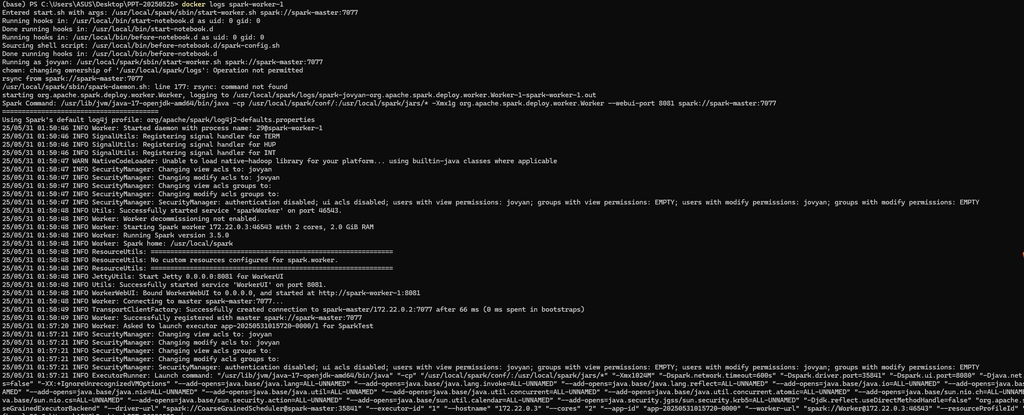

  - 查看网络
    - `docker network inspect sparknet`

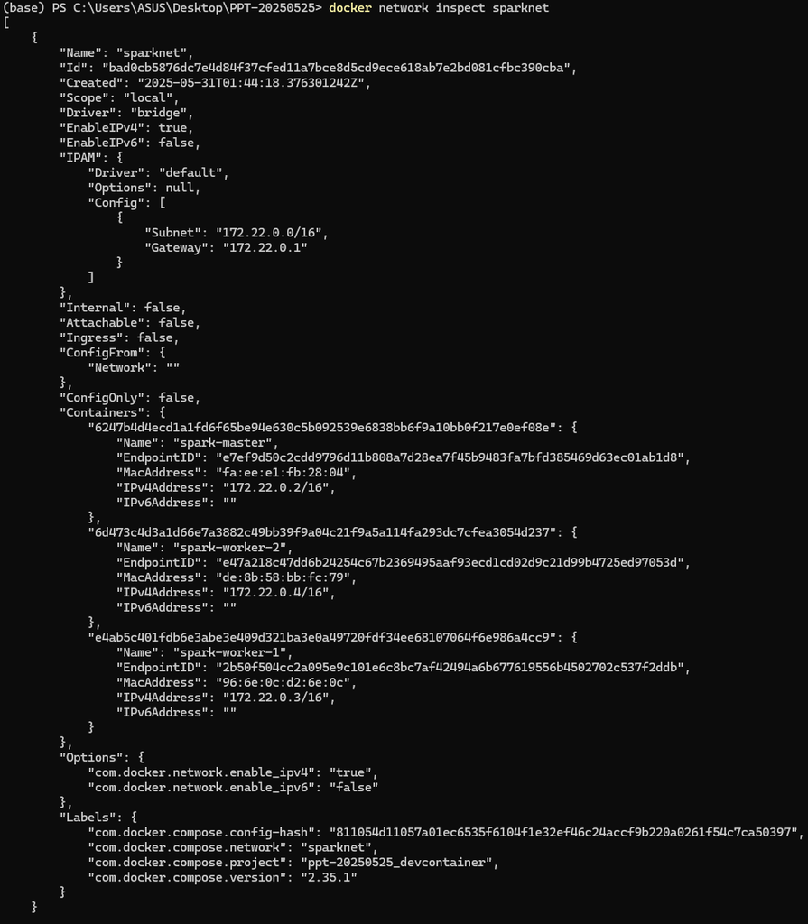

  - Ping网络
    - `docker exec spark-worker-1 ping -c 3 spark-master`

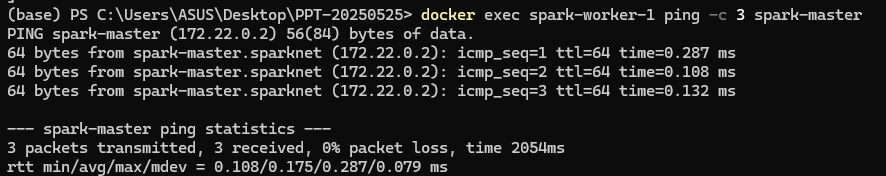

```python
# This script retrieves cluster information from a Spark application using the Spark REST API.
import requests
import json

def get_cluster_info():
    """Get cluster information using Spark REST API"""
    try:
        # Get UI URL from SparkContext
        ui_url = sc.uiWebUrl

        # Get application ID
        app_id = sc.applicationId

        # Make REST API request
        response = requests.get(f"{ui_url}/api/v1/applications/{app_id}/executors")

        if response.status_code == 200:
            executors = response.json()

            # Print cluster information
            print(f"Cluster Information:")
            print(f"- Number of executors: {len(executors)}")
            print(f"- Total nodes (including driver): {len(executors) + 1}")

            # Print detail for each executor
            for idx, executor in enumerate(executors):
                print(f"\nExecutor {idx}:")
                print(f"- ID: {executor.get('id')}")
                print(f"- Host: {executor.get('hostPort')}")
                print(f"- Active: {executor.get('isActive')}")
                print(f"- Memory Used: {executor.get('memoryUsed')} / {executor.get('maxMemory')}")
                print(f"- Cores: {executor.get('totalCores')}")
        else:
            print(f"Failed to get executor info. Status code: {response.status_code}")

    except Exception as e:
        print(f"Error getting cluster info: {str(e)}")

# Run the function
get_cluster_info()
```

```
Cluster Information:
- Number of executors: 3
- Total nodes (including driver): 4

Executor 0:
- ID: driver
- Host: spark-master:42291
- Active: True
- Memory Used: 0 / 455501414
- Cores: 0

Executor 1:
- ID: 1
- Host: 172.22.0.4:40559
- Active: True
- Memory Used: 0 / 455501414
- Cores: 2

Executor 2:
- ID: 0
- Host: 172.22.0.3:38297
- Active: True
- Memory Used: 0 / 455501414
- Cores: 16
```

- 成功部署PySpark Standalone模式docker desktop界面

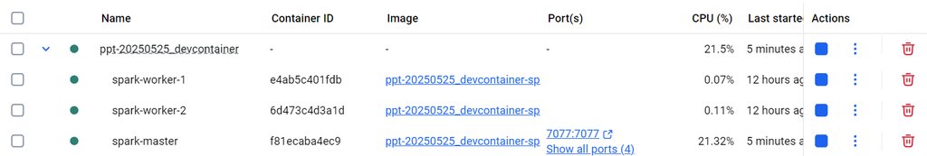

- Spark Master Web UI (http://localhost:8080/ )

[figure not shown]

[figure not shown]

```python
# 从指定的文件创建一个 RDD。
data = sc.textFile('demo_file.txt')
print(type(data))
# collect() 会将 RDD 中的元素收集到一个列表中。
data.collect()
```

```
<class 'pyspark.rdd.RDD'>
```

```
['This is just a demo file. ',
 'Normally, a file this small would have no reaon to be on HDFS.']
```